# Data analysis and Visualization

This project will analyse the tweet archive of Twitter user @dog_rates, also known as WeRateDogs. WeRateDogs is a Twitter account that rates people's dogs with a humorous comment about the dog.  
The dataset is stored in "twitter_archive_master.csv" file, this dataset is gathered from different resources and has been cleaned for analysis.

This analysys will be about three insights that van be concluded from our data.

1. Is the number of followers affect the number of retweets?
2. What is the most predictable dog's breez from the nueral network
3. Is there a specific stage where dogs get's higher rating?

```python
# Import the data
import pandas as pd
df = pd.read_csv('twitter_archive_master.csv')
df.head()
```

|  | tweet_id | timestamp | source | text | expanded_urls | rating_numerator | rating_denominator | name | stage | tweet_URL | breed prediction | retweet_count | favorite_count | num_of_hashtag | followers_count |
| --- | --- | --- | --- | --- | --- | --- | --- | --- | --- | --- | --- | --- | --- | --- | --- |
| 0 | 892420643555336193 | 2017-08-01 16:23:56+00:00 | <a href="http://twitter.com/download/iphone" r... | This is Phineas. He's a mystical boy. Only eve... | https://twitter.com/dog_rates/status/892420643... | 13 | 10 | Phineas | NaN | https://t.co/MgUWQ76dJU | NaN | 8853 | 39467 | 0 | 3200889 |
| 1 | 892177421306343426 | 2017-08-01 00:17:27+00:00 | <a href="http://twitter.com/download/iphone" r... | This is Tilly. She's just checking pup on you.... | https://twitter.com/dog_rates/status/892177421... | 13 | 10 | Tilly | NaN | https://t.co/0Xxu71qeIV | Chihuahua | 6514 | 33819 | 0 | 3200889 |
| 2 | 891815181378084864 | 2017-07-31 00:18:03+00:00 | <a href="http://twitter.com/download/iphone" r... | This is Archie. He is a rare Norwegian Pouncin... | https://twitter.com/dog_rates/status/891815181... | 12 | 10 | Archie | NaN | https://t.co/wUnZnhtVJB | Chihuahua | 4328 | 25461 | 0 | 3200889 |
| 3 | 891689557279858688 | 2017-07-30 15:58:51+00:00 | <a href="http://twitter.com/download/iphone" r... | This is Darla. She commenced a snooze mid meal... | https://twitter.com/dog_rates/status/891689557... | 13 | 10 | Darla | NaN | https://t.co/tD36da7qLQ | NaN | 8964 | 42908 | 0 | 3200889 |
| 4 | 891327558926688256 | 2017-07-29 16:00:24+00:00 | <a href="http://twitter.com/download/iphone" r... | This is Franklin. He would like you to stop ca... | https://twitter.com/dog_rates/status/891327558... | 12 | 10 | Franklin | NaN | https://t.co/AtUZn91f7f | basset | 9774 | 41048 | 1 | 3200889 |

## Insight 1

There is a negative correlation between the number of retweets and the number of followers, opposite to expectation

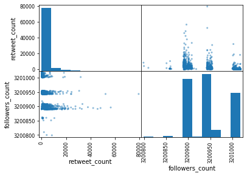

```python
# Compute the ratio of the followers_count to the retweet_count and draw the histogram
import matplotlib.pyplot as plt
follower_retweet = df[['retweet_count','followers_count']]
pd.plotting.scatter_matrix(follower_retweet);
```

```python
#Compute the correlation coefficient
follower_retweet.corr()
```

|  | retweet_count | followers_count |
| --- | --- | --- |
| retweet_count | 1.000000 | -0.346462 |
| followers_count | -0.346462 | 1.000000 |

## Insight 2

the golden_retriever is the most predictable dog's breed by the neural network

```python
df['breed prediction'].value_counts()
```

```
golden_retriever      139
Labrador_retriever     95
Pembroke               88
Chihuahua              79
pug                    54
                     ...
Scotch_terrier          1
EntleBucher             1
silky_terrier           1
Japanese_spaniel        1
groenendael             1
Name: breed prediction, Length: 111, dtype: int64
```

## Insight 3

Most of the dogs are in pupper stage. The puppo stage has higher rating but the slight difference gives an intuition that the stage doesn't effect the rating  
I compute the sum of rating ratios of each stage, the number of dogs on each stage, and devide these two numbers to avoid bias for groups with higher count.  
The results are very near. The puppo stage gets the highest rate_to_stage ratio but this doesn't definitly told us that it's the best stage, as the count for the puppo stage is too small (25) which make the result bigger.

```python
df_rating = df[['stage','rating_numerator','rating_denominator']]
df_rating['rate_ratio'] = df_rating.rating_numerator / df_rating.rating_denominator
df_rating.sample(5)
groups = df_rating.groupby('stage').sum()

counts = pd.DataFrame(df_rating.stage.value_counts())
counts.reindex(groups.index)
counts.rename(columns = {'stage':'stage_count'}, inplace = True)

result = pd.concat([groups, counts], axis=1, join='inner')
result['rate_to_stage'] = result.rate_ratio/result.stage_count
result
```

|  | rating_numerator | rating_denominator | rate_ratio | stage_count | rate_to_stage |
| --- | --- | --- | --- | --- | --- |
| doggo | 970 | 820 | 97.0 | 82 | 1.182927 |
| floofer | 118 | 100 | 11.8 | 10 | 1.180000 |
| pupper | 2446 | 2260 | 244.6 | 226 | 1.082301 |
| puppo | 302 | 250 | 30.2 | 25 | 1.208000 |